# Treg/Tconv: comparison of Duguet’s data set with expression and proteomic datasets

Marie Locard-Paulet

20 novembre 2015

Here I want to compare our dataset with previous works. I will work with the supplementary data of two papers:

*Foxp3 Transcription-Factor-Dependent and -Independent Regulation of the Regulatory T Cell Transcriptional Signature. Jonathan A. Hill, Markus Feuerer, Kaley Tash, Sokol Haxhinasto, Jasmine Perez, Rachel Melamed, Diane Mathis, and Christophe Benoist1,*

DOI 10.1016/j.immuni.2007.09.010

*Transcription Factor 7 Limits Regulatory T Cell Generation in the Thymus. Melanie M. Barra, David M. Richards, Jenny Hansson, Ann-Cathrin Hofer, Michael Delacher, Jan Hettinger, Jeroen Krijgsveld and Markus Feuerer*

J Immunol published online 31 August 2015

The table with our MS results is the table (input table) `OutputTables/TotalAnalysisTconvTreg.txt`.

# Comparison with the expression dataset

Hill et al. 2007.

I use the expression data file `Raw/ExpressionData/GSE7460_series_matrix.txt` downloaded from the [Omnibus expression datasets webpage](http://www.ncbi.nlm.nih.gov/geo/). I have computed a ratio of normalised intensities Treg/Tconv (Markdown file `ExpressionAnalysis.Rmd` in the `ExpressionData` folder). All is saved in the file `ExpData.Rdata` that I load (`nmat` contains the fold changes ratio, `mat3` the raw expression values).

- I perform linear regressions first, then I make a graphical representation.
- In the expression table, I indicate wich genes are not present in our MS data set by adding a column called “PresenceInOurDataset”: “Present in our MS dataset” means we quantify the corresponding protein; “not in our MS dataset” means that we don’t identify the corresponding protein in our MS dataset.
- I then add a column named “MeanExpression” to our restult table that contains the mean expression observed for the corresponding protein in the expression dataset.

The final table is saved as `OutputTables/SignatureFoxp3.txt`.

```
##
## Call:
## lm(formula = tab1$FC ~ tab1$MeanExpression)
##
## Residuals:
##     Min      1Q  Median      3Q     Max
## -2.6948 -0.2401 -0.0391  0.2064  3.8769
##
## Coefficients:
##                      Estimate Std. Error t value Pr(>|t|)
## (Intercept)         -0.007155   0.007711  -0.928    0.353
## tab1$MeanExpression  1.015687   0.020941  48.501   <2e-16 ***
## ---
## Signif. codes:  0 '***' 0.001 '**' 0.01 '*' 0.05 '.' 0.1 ' ' 1
##
## Residual standard error: 0.4702 on 3819 degrees of freedom
## Multiple R-squared:  0.3812, Adjusted R-squared:  0.381
## F-statistic:  2352 on 1 and 3819 DF,  p-value: < 2.2e-16
```

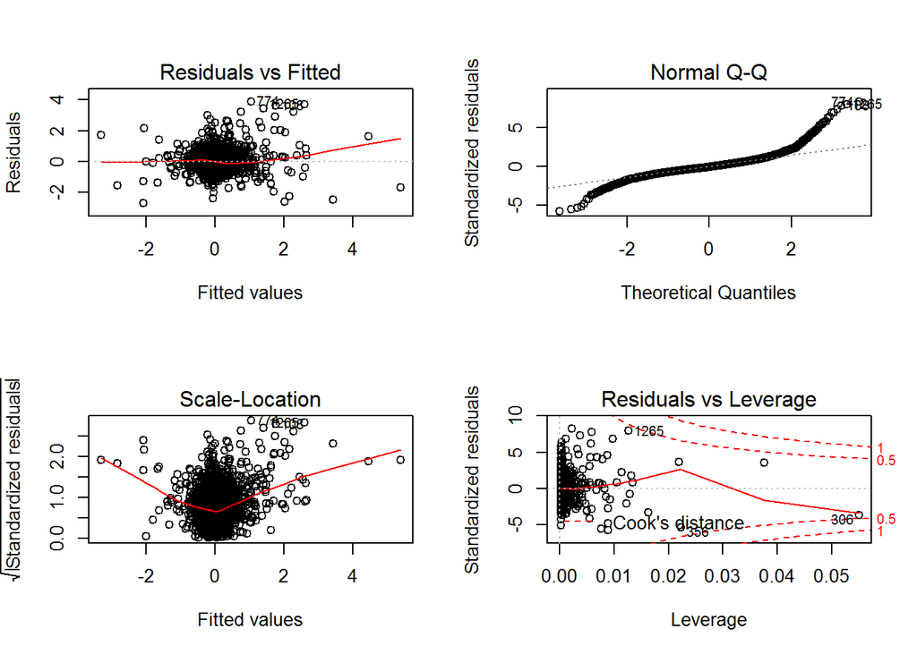

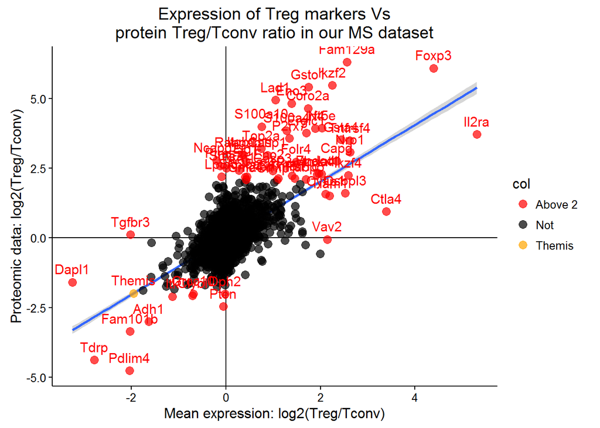

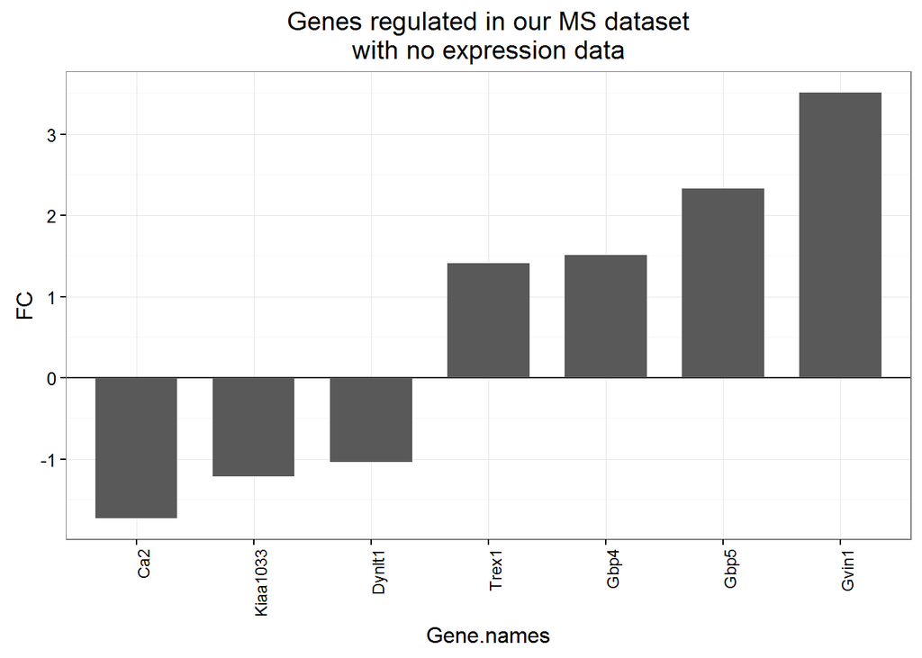

| Pres | Freq |
| --- | --- |
| not in our MS dataset | 16852 |
| Present in our MS dataset | 3818 |

There are 3818 unique genes that are present in the expression table and quantified in our MS dataset. There are 7 genes that are regulated in our dataset and not present in the expression dataset. These are presented in the previous figure.

The table `OutputTables/signatureFoxp3.txt` contains the initial expression data with an additional column stating if the gene is quantified in our MS dataset.

The table `OutputTables/TableAll.txt` contains our result table with the additional columns of mean in each dataset, including a `mapping` column that is the first Majority protein ID that I use to merge the other datasets to ours (see the following section).

# Comparison with the proteomic dataset

Barra et al. 2015.

I use the Supplemental Table 1: Calculated dataset of proteins differentially expressed between Treg cells and Tconv cells.

I use all the protein accessions in the column `Accession` as input in [Uniprot ID mapper](http://www.uniprot.org/uploadlists/) to get all possible protein accessions of these proteins: `Raw/ProteomicsData/uniprot-yourlist%3AM2015113099G02LBX6Z-GenesMSinput.tab`.

```
##
## Call:
## lm(formula = tab1$FC ~ tab1$ProteomicRatioTregTconv)
##
## Residuals:
##     Min      1Q  Median      3Q     Max
## -2.7896 -0.1988 -0.0283  0.1460  4.5515
##
## Coefficients:
##                               Estimate Std. Error t value Pr(>|t|)
## (Intercept)                  -0.023218   0.007194  -3.227  0.00126 **
## tab1$ProteomicRatioTregTconv  0.773371   0.014050  55.044  < 2e-16 ***
## ---
## Signif. codes:  0 '***' 0.001 '**' 0.01 '*' 0.05 '.' 0.1 ' ' 1
##
## Residual standard error: 0.4298 on 3694 degrees of freedom
## Multiple R-squared:  0.4506, Adjusted R-squared:  0.4505
## F-statistic:  3030 on 1 and 3694 DF,  p-value: < 2.2e-16
```

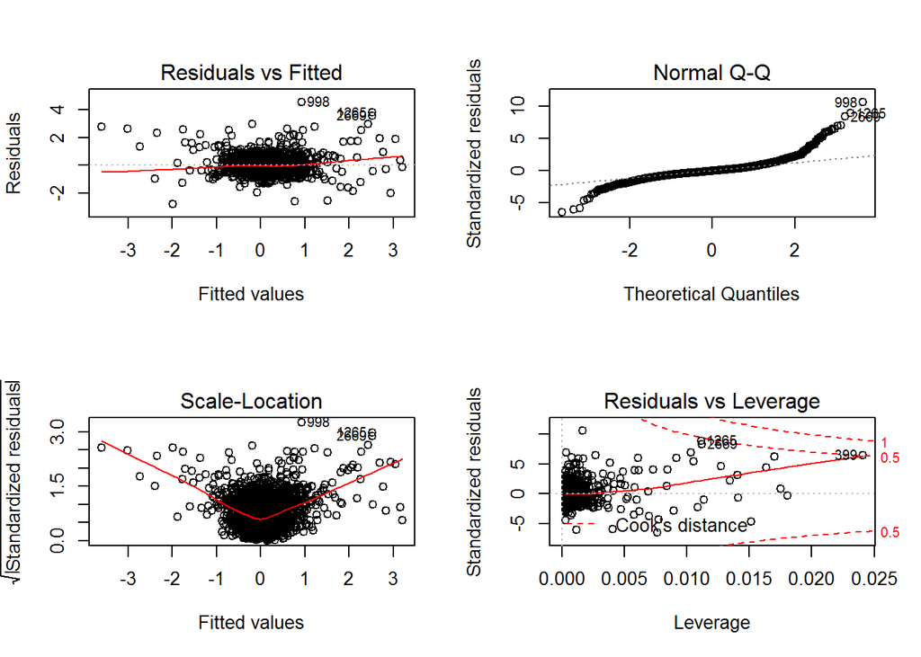

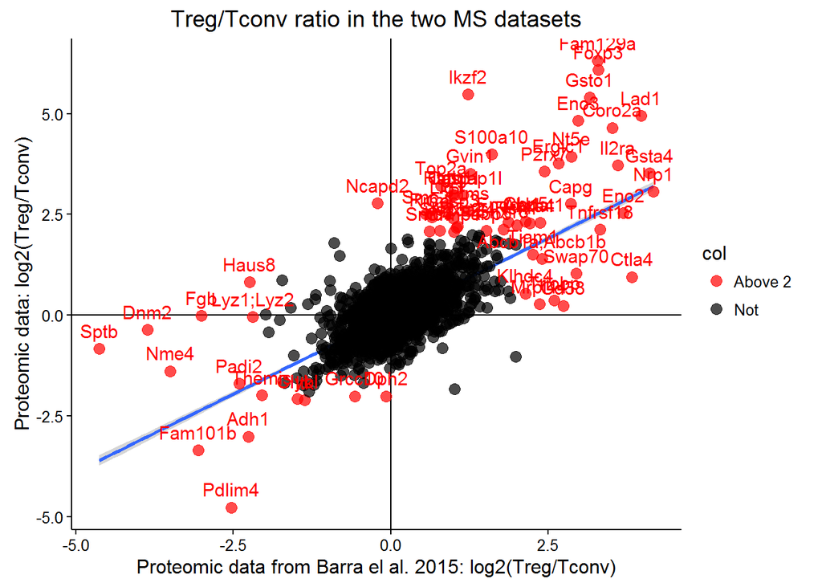

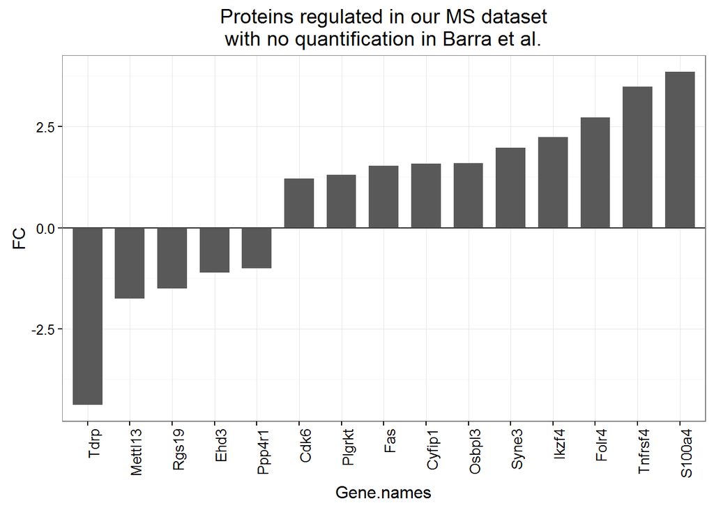

| Pres | Freq |
| --- | --- |
| not in our MS dataset | 1543 |
| Present in our MS dataset | 3775 |

# Creation heatmap with the three datasets.

In our dataset, there are 37 rows with no gene names, 3 corresponding to H2-D1 and 2 for Tmpo (these are different isoforms, in the case of Tmpo they don’t present the same abundancy).

For this figure, I manually remove the row with no gene name, and corresponding to `Majority.protein.IDs` == “P14427” and “P01900;P01895” for H2-D1 (highest pval, no adjusted pval); “Q61029” for Tmpo (highest pval, no adjusted pval).

In the proteomic data table, some isoforms remain (duplicated gene names). So I use `Accession` as row names. For each gene, I keep the quan value corresponding to the SwissProt identification with the maximum number of Unique + razor peptides.

For the tilemap, I select the genes that have a mean FC >= 1 or <= -1 in 2 datasets. Then, I present 50% of the top hits ordered by mean FC: `Figures/TregTconv3DS.pdf`.

```
##
##       H2-D1  Tmpo
##    37     3     2
```

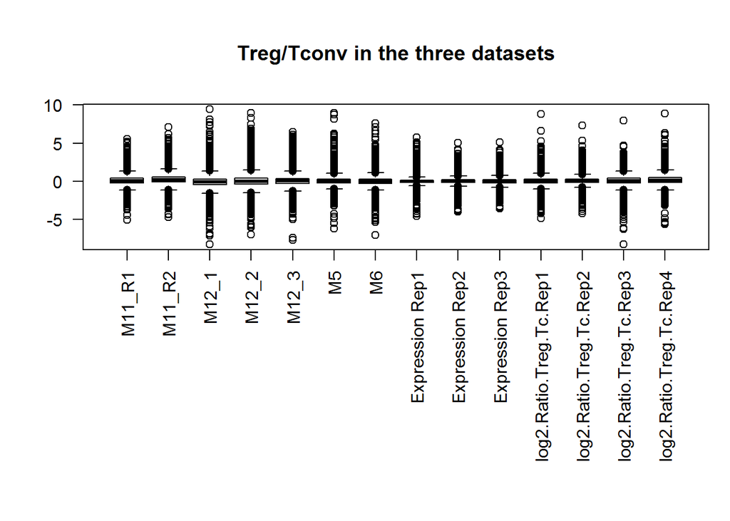

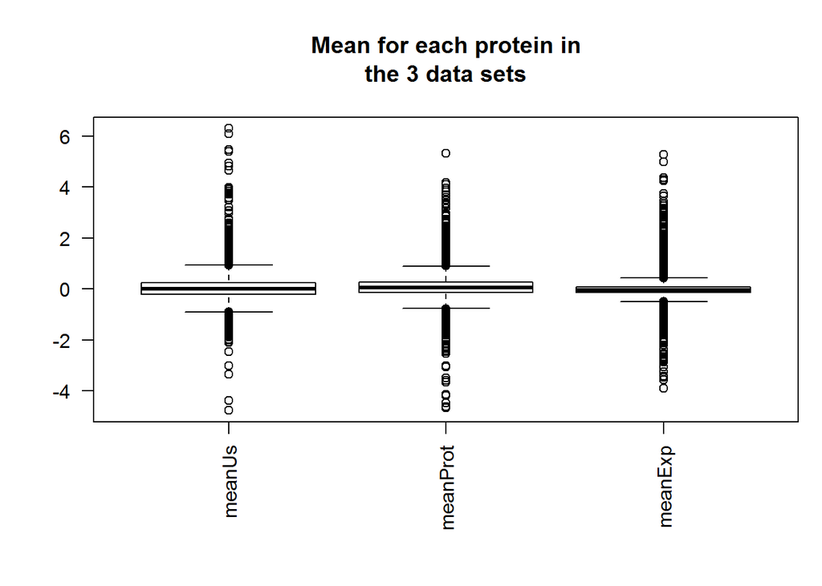

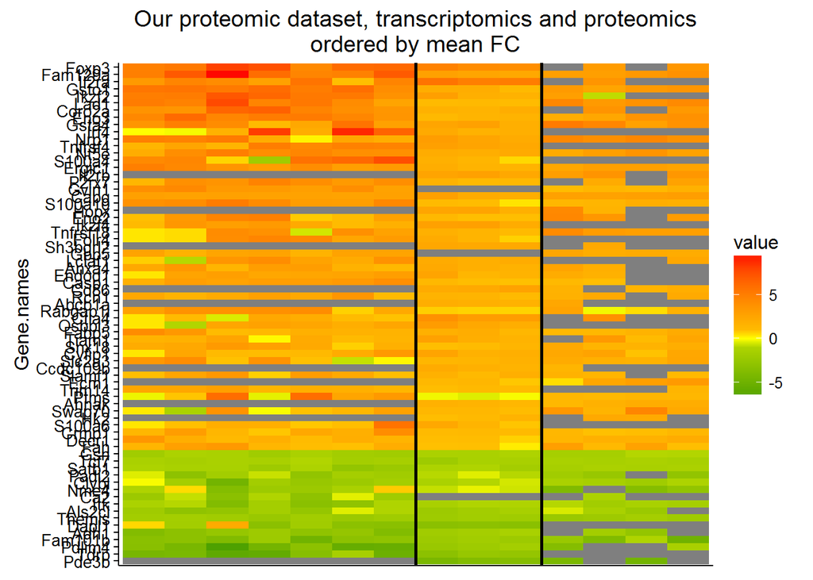

The table used for the final heatmap is: `OutputTables/HeatMapProtExp_Table.txt`.